# TASK2 使用igraph包创建网络

张坊

2021/3/11

### 准备工作

```r
cat("\014");rm(list=ls())        #清除工作环境
```

```r
#加载相应的包
library("igraph")
library("RColorBrewer")
```

### 作业一：找到football.csv数据，尝试利用该数据使用graph_from_data_frame()构建网络。

```r
data = read.csv("F:\\WODEWENJIAN\\football.csv",head = T)  # 导入足球比赛数据

g = graph_from_data_frame(data, directed = F)      # 用graph_from_data_frame()函数创建无向网络
g                                                  # 查看网络结构
```

```
## IGRAPH 58c0f19 UN-- 115 613 --
## + attr: name (v/c)
## + edges from 58c0f19 (vertex names):
##  [1] BrighamYoung--FloridaState       BrighamYoung--NewMexico
##  [3] BrighamYoung--SanDiegoState      BrighamYoung--Wyoming
##  [5] BrighamYoung--Utah               BrighamYoung--Virginia
##  [7] BrighamYoung--Syracuse           BrighamYoung--ColoradoState
##  [9] BrighamYoung--MississippiState   BrighamYoung--UtahState
## [11] BrighamYoung--AirForce           BrighamYoung--NevadaLasVegas
## [13] FloridaState--NorthCarolinaState FloridaState--Florida
## [15] FloridaState--Virginia           FloridaState--GeorgiaTech
## + ... omitted several edges
```

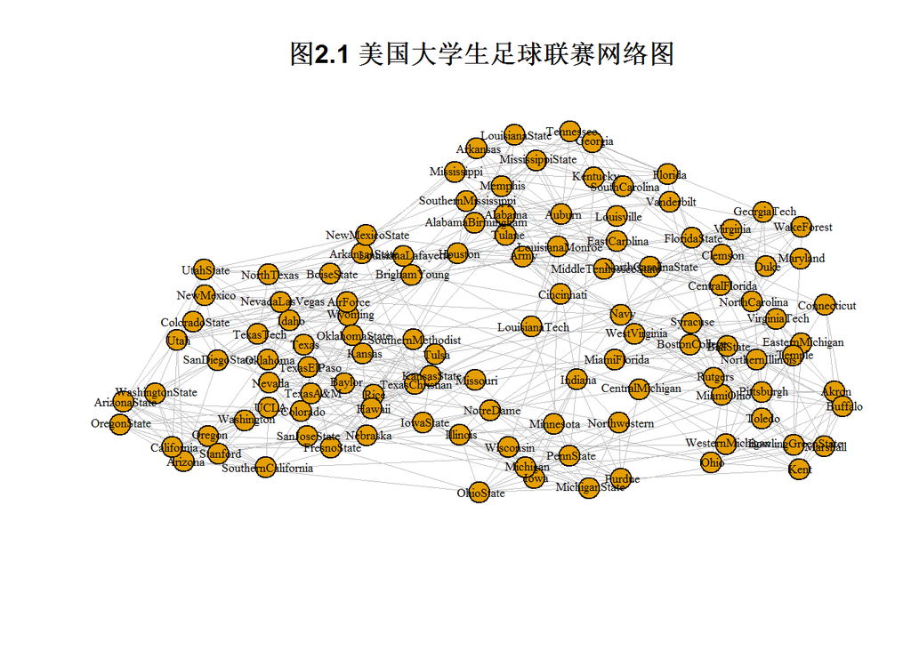

```r
set.seed(100)        # 生成随机数种子，使每次绘制出的图相同
plot(g,
     vertex.label.cex=.55,        #节点的标签字号
     vertex.label.dist=.1,        #节点的标签的位置
     vertex.label.color="black",  #节点的标签颜色
     vertex.size=6,               #节点的大小
     edge.width=.95,               #边的宽度
     edge.color='gray',           #边的颜色
     asp=.5,                      #对图进行缩放
     margin=-.07,                 #调整边距
     main = "图2.1 美国大学生足球联赛网络图")
```

### 作业二：对生成的网络做适当解读。

在上述任务中，我们使用了R语言igraph包中的graph_from_data_frame()函数实现了College Football网络的构建，使用的数据为football数据。College Football网络是根据美国大学生足球联赛创建的一个真实的社会网络。共包含115个节点和613条边,其中每个节点代表一支足球队,连边表示两只球队之间进行过一场比赛。

由图2.1可知，College Football网络是一个无向网络，与节点相关的边的数量代表了该球队参加的比赛的次数。

### 选做题

找到game of thrones文件夹中的got-edges.csv数据，尝试利用该数据使用graph_from_data_frame()构建无向网络。

```r
data1 = read.csv("F:\\WODEWENJIAN\\got-edges.csv",head = T)  # 导入权力的游戏数据
data1 = data1[order(data1$Weight, decreasing=T),]   #将Weight变量按降序排列作为索引
```

```r
network = graph_from_data_frame(d=data1, directed=F)      # 用graph_from_data_frame()函数创建无向网络
network         # 查看网络结构
```

```
## IGRAPH 5928026 UN-- 107 352 --
## + attr: name (v/c), Weight (e/n)
## + edges from 5928026 (vertex names):
##  [1] Bran    --Hodor    Jaime   --Brienne  Sansa   --Tyrion   Jon     --Mance
##  [5] Bran    --Meera    Joffrey --Tyrion   Jon     --Ygritte  Jon     --Samwell
##  [9] Daenerys--Jorah    Arya    --Sandor   Bran    --Jojen    Cersei  --Tyrion
## [13] Arya    --Gendry   Catelyn --Robb     Samwell --Grenn    Hodor   --Meera
## [17] Tywin   --Tyrion   Jaime   --Cersei   Samwell --Gilly    Sansa   --Margaery
## [21] Bran    --Rickon   Hodor   --Jojen    Sansa   --Joffrey  Samwell --Craster
## [25] Jojen   --Meera    Robb    --Edmure   Stannis --Davos    Samwell --Aemon
## [29] Jaime   --Tyrion   Jon     --Qhorin   Tyrion  --Bronn    Jon     --Aemon
## + ... omitted several edges
```

```r
cols<-colorRampPalette(c('black','brown','gray','antiquewhite'))(360)    #生成360个颜色
```

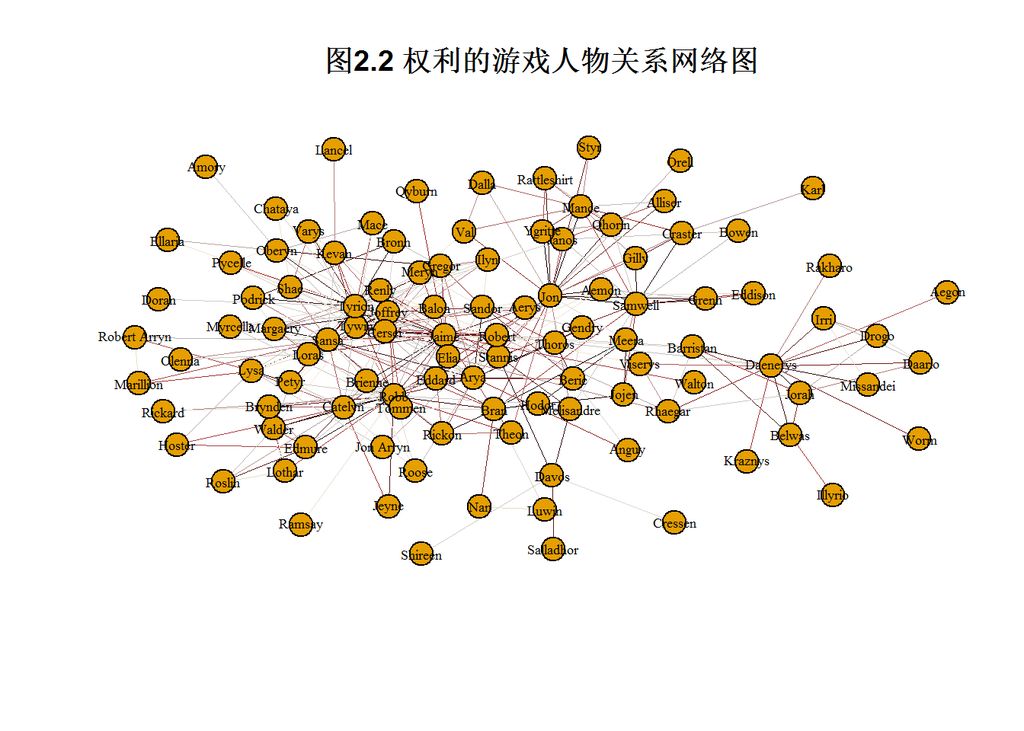

```r
set.seed(100)         # 生成随机数种子，使每次绘制出的图相同

plot(network,
     layout=layout.lgl,                       #设置布局方式
     vertex.label.cex=.55,                    #节点的标签字号
     vertex.label.dist=.01,                   #节点的标签的位置
     vertex.label.color='black',              #节点的标签颜色
     vertex.size=6,                           #节点的大小
     edge.width=.7,                           #边的宽度
     asp=.5,                                  #对图进行缩放
     margin=-.07,                             #调整边距
     edge.color = cols,                       #边的颜色
     main = "图2.2 权利的游戏人物关系网络图")
```

在上述任务中，我们使用了R语言igraph包中的graph_from_data_frame()函数实现了game of thrones网络的构建，使用的数据为got-edges数据。game of thrones网络是根据权力的游戏中的人物关系构建的网络，是一个无向但有权重的网络。数据包括了107个节点，352条边。每个节点代表一个人物，每条边表示两个人物在一句话（大概15个单词）中同时出现一次。

在图2.2中，由于节点和边的数量过多，每条边的权数不便于展示出来。所以，我们采用不同的颜色来表示每条边的权重，颜色越深的边表示权重越大。同时，与更多的边相连接的节点表示该人物与剧中更多的人物有关系。